# fifaJup

##### imports

```python
import time
from pprint import pprint
import numpy as np
import pandas as pd
%matplotlib inline
import matplotlib.pyplot as plt
from mpl_toolkits.mplot3d import Axes3D
import seaborn as sns
sns.set(style="darkgrid")
sns.set_palette("bright")
from sklearn.model_selection import train_test_split
from sklearn.svm import SVC
from sklearn.metrics import classification_report
from sklearn.ensemble import RandomForestClassifier, AdaBoostClassifier
from torch import nn
import torch.nn.functional as F
from torch.autograd import Variable
import torch
import scipy.stats as st
```

##### code

```python
bookStart = time.time()
def vis_null(df):
    sns.heatmap(df.isnull(), cbar=False, cmap="YlGnBu_r")
    plt.show()

def standardize(X):
    standy = (X - np.mean(X, axis=0))/np.std(X,axis=0)
    return standy

def map_positions(df, print_dict=False):
    posList = list(df.Position.unique())
    posDict = {posList[i]:float(i) for i in range(len(posList))}
    df['Position'] = df['Position'].map(posDict).astype('float')
    if print_dict:
        print('Position Mappings: {}'.format(posDict))
    return df

def convert_to_array(df, print_info=False):
    X = df.iloc[:,1:].to_numpy(dtype='float')
    b = df.loc[:,'Position'].to_numpy(dtype='float')
    if print_info:
        print('type: \n\tX: {}\n\tb: {}'.format(type(X), type(b)))
        print('dtype: \n\tX: {}\n\tb: {}'.format(X.dtype, b.dtype))
        print('shape: \n\tX: {}\n\tb: {}'.format(X.shape, b.shape))
    return (X, b)

def create_test_train_split(X, b, test_size=0.33, random=False):
    if random:
        output = train_test_split(X, b, test_size=test_size, random_state=None)
    else:
        output = train_test_split(X, b, test_size=test_size, random_state=27)
    return output

def apply_PCA(x, n_components=1):
    shift = x - np.mean(x, axis=0) # normalized data
    u, s, v = np.linalg.svd(shift, compute_uv=True, full_matrices=False)
    v = v.T
    return np.dot(x, v[:,:n_components])

def plot_2D_proj(X, labels=None):
    fig = plt.figure()
    proj_2d_data = apply_PCA(X, 2)
    fig.gca().scatter(proj_2d_data[:,0],proj_2d_data[:,1],c=labels)
    fig.gca().set_title('PCA 2D transformation')
    return fig

def plot_3D_proj(X, labels=None):
    fig = plt.figure()
    ax = fig.add_subplot(111,projection='3d')
    proj_3d_data = apply_PCA(X, 3)
    ax.scatter(proj_3d_data[:,0],proj_3d_data[:,1],proj_3d_data[:,2],c=labels)
    fig.gca().set_title('PCA 3D transformation')
    return fig
```

```python
class SVM():
    def __init__(self, X, b, test_size=0.33, random=False):
        self.X = X
        self.b = b
        self.trainX, self.testX, self.trainb, self.testb = create_test_train_split(self.X, self.b, test_size=test_size, random=random)

    def create_fit(self, kernel='rbf', c=1.0, dfs='ovr', gamma='auto'):
        self.clf = SVC(kernel=kernel, decision_function_shape=dfs, gamma=gamma, C=c)
        self.clf.fit(self.trainX, self.trainb)

    def calc_performance(self, X, b):
        preds = self.clf.predict(X)
        acc = (b == preds).sum()/float(X.shape[0])
        return acc
```

```python
def svm_helper(C, gamma, printq=True):
    svm = SVM(X,b)
    performance_dict = {}
    for kern in ['poly','rbf','sigmoid']:
        svm.create_fit(kernel=kern, c=C, gamma=gamma)
        train_acc = svm.calc_performance(svm.trainX,svm.trainb)
        test_acc = svm.calc_performance(svm.testX,svm.testb)
        performance_dict[kern+'_train'] = train_acc
        performance_dict[kern+'_test'] = test_acc
    results = performance_dict
    if printq:
        sns.barplot(y=list(results.keys()),x=list(results.values())).set_xlabel('Accuracy Score')
        plt.ylabel('Kernal_Split')
        pprint(results)
    return results
```

```python
class RandomForest():
    def __init__(self, X, b, random=False):
        self.X = X
        self.b = b
        self.trainX, self.testX, self.trainb, self.testb = create_test_train_split(self.X, self.b, random=random)

    def create_fit(self, bag=True, n_estimators=100, max_features='sqrt'):
        if bag:
            self.clf = RandomForestClassifier(n_estimators=n_estimators, max_features=max_features)
            self.clf.fit(self.trainX, self.trainb)
        else: # boosting
            self.clf = AdaBoostClassifier(n_estimators=n_estimators)
            self.clf.fit(self.trainX, self.trainb)

    def calc_performance(self, X, b):
        preds = self.clf.predict(X)
        acc = (b == preds).sum()/float(X.shape[0])
        return acc
```

```python
def rf_helper(bag, max_features, PCA=False):
    rf = RandomForest(X, b)
    performance_dict = {}
    train = []
    test = []
    for i in range(1,101):
        rf.create_fit(bag=bag, n_estimators=i, max_features=max_features)
        train.append(rf.calc_performance(rf.trainX,rf.trainb))
        test.append(rf.calc_performance(rf.testX,rf.testb))
    performance_dict['train'] = train
    performance_dict['test'] = test
    results = pd.DataFrame.from_dict(performance_dict)
    sns.lineplot(data=results, dashes=False).set_xlabel('# of Estimators')
    print('Max test score: {}'.format(results['test'].max()))
    plt.ylabel('Accuracy Score')
```

```python
class Net(torch.nn.Module):
    def __init__(self, X, b, n_hidden, n_output, activ_func='relu', random=False):
        self.activ_func = activ_func
        self.n_hidden = n_hidden
        super(Net, self).__init__()
        self.X = X
        self.b = b
        self.trainX, self.testX, self.trainb, self.testb = create_test_train_split(self.X, self.b, random=random)
        self.trainX = Variable(torch.from_numpy(self.trainX).float())
        self.testX = Variable(torch.from_numpy(self.testX).float())
        self.trainb = Variable(torch.from_numpy(self.trainb).float())
        self.testb = Variable(torch.from_numpy(self.testb).float())
        self.finalTestX = Variable(torch.from_numpy(Xho).float())
        self.finalTestb = Variable(torch.from_numpy(bho).float())
        self.hidden1 = torch.nn.Linear(X.shape[1], n_hidden[0])
        self.hidden2 = torch.nn.Linear(n_hidden[0], n_hidden[1])
        if len(n_hidden) >= 3:
            self.hidden3 = torch.nn.Linear(n_hidden[1], n_hidden[2])
        if len(n_hidden) >= 4:
            self.hidden4 = torch.nn.Linear(n_hidden[2], n_hidden[3])
        if len(n_hidden) >= 5:
            self.hidden5 = torch.nn.Linear(n_hidden[3], n_hidden[4])
        self.out = torch.nn.Linear(n_hidden[len(n_hidden)-1], n_output)   # output layer

    def forward(self, x):
        if self.activ_func == 'relu':
            x = F.relu(self.hidden1(x)) # activation function for hidden layer
            x = F.relu(self.hidden2(x))
            if len(self.n_hidden) >= 3:
                x = F.relu(self.hidden3(x))
            if len(self.n_hidden) >= 4:
                x = F.relu(self.hidden4(x))
            if len(self.n_hidden) >= 5:
                x = F.relu(self.hidden5(x))
        elif self.activ_func == 'sigmoid':
            x = (self.hidden1(x).sigmoid()) # activation function for hidden layer
            x = (self.hidden2(x).sigmoid())
            if len(self.n_hidden) >= 3:
                x = (self.hidden3(x).sigmoid())
            if len(self.n_hidden) >= 4:
                x = (self.hidden4(x).sigmoid())
            if len(self.n_hidden) >= 5:
                x = (self.hidden5(x).sigmoid())
        x = self.out(x)
        return x

    def train_net(self, num_epochs=1000, print_iters=False):
        performance_dict = {}
        train = []
        test = []
        x = self.trainX
        y = self.trainb
        start = time.time()
        for t in range(num_epochs):
            out = net(x)
            loss = loss_func(out, y.long())
            optimizer.zero_grad()
            loss.backward()
            optimizer.step()
            if t >= 0:
                train_acc = self.test_net(test_unseen=False,out=out,y=y)
                train.append(train_acc)
                test.append(self.test_net(test_unseen=True))
                if t % 100 == 0 and print_iters:
                    print('iteration: {}'.format(t))
                    print('train accuracy: {}'.format(train_acc))
        performance_dict['train'] = train
        performance_dict['test'] = test
        results = pd.DataFrame.from_dict(performance_dict)
        return (results, time.time()-start, out)

    def test_net(self, out='', y='', test_unseen=False, test_final=False):
        if test_unseen:
            y = self.testb
            out = net(self.testX)
        elif test_final:
            y = self.finalTestb
            out = net(self.finalTestX)
        prediction = torch.max(out, 1)[1]
        pred_y = prediction.data.numpy()
        accuracy = float((pred_y == y.data.numpy()).astype(int).sum()) / float(y.data.numpy().size)
        return accuracy
```

# Predicting Player Position in FIFA19 using Multiclass Classification

## Grant Cloud

## CS 4641 - Final Project

### Introduction to the Dataset

### Description of the Algorithms

### Tuning the Hyperparameters

### Comparing Algorithm Performance

### Conclusion

### Acknowledgements

### Future Research

## Introduction to the Dataset

The FIFA 19 dataset is sourced from Kaggle<sup>2</sup> and then wrangled using the submitted file fifaWrangler.py.

```python
df = pd.read_csv('fifa19wr.csv', index_col=0)
print('df Shape:                 {}'.format(df.shape))
print('Number of Features:       {}'.format(df.shape[1]-1))
print('Number of Unique Players: {}'.format(df.shape[0]))
print('Feature Set: \n',df.columns[1:])
```

```
df Shape:                 (14087, 36)
Number of Features:       35
Number of Unique Players: 14087
Feature Set:
 Index(['Age', 'Overall', 'Preferred Foot', 'Body Type', 'Height', 'Weight',
       'Crossing', 'Finishing', 'HeadingAccuracy', 'ShortPassing', 'Volleys',
       'Dribbling', 'Curve', 'FKAccuracy', 'LongPassing', 'BallControl',
       'Acceleration', 'SprintSpeed', 'Agility', 'Reactions', 'Balance',
       'ShotPower', 'Jumping', 'Stamina', 'Strength', 'LongShots',
       'Aggression', 'Interceptions', 'Positioning', 'Vision', 'Penalties',
       'Composure', 'Marking', 'StandingTackle', 'SlidingTackle'],
      dtype='object')
```

The wrangled dataset (fifa19wr.csv) contains 14087 unique players from the video game FIFA 19. Each player has 35 skills (features) with values ranging from 0.0 to 100.0 (other than Body Type and Preferred Foot which are label encoded and binary encoded respectively). Higher skill values correspond to higher performance when performing an act that involves that skill. For example, a player with 99.0 pass accuracy will outperform a player with 1.0 pass accuracy when passing.

The dataset also contains a column that tells us each player's position (class label).

```
Number of Unique Positions: 10
```

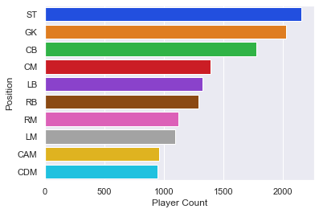

```python
print('Number of Unique Positions: {}'.format(df.Position.value_counts().shape[0]))
sns.countplot(y=df['Position'], order=df.Position.value_counts().index).set_xlabel('Player Count')
```

There are 10 unique positions in this dataset and the positions correspond to the top 10 positions in the original dataset based on the number of players who play that position. Each position in this dataset contains over 900 instances, which means there is plenty of data to train and test on.

```
null values (white=null):
```

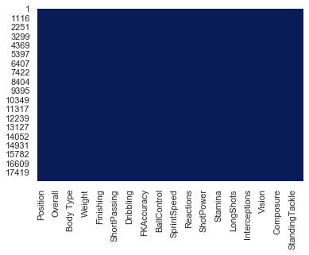

```python
print('null values (white=null):')
vis_null(df) # show null values in the dataframe
```

Since the data has already been wrangled, there are no null or missing values in the dataset.

In order to perform machine learning on the dataset, the position column is label encoded and the dataframe is converted to a numpy array. The position encoding dictionary can be seen below.

```python
posMap = df.Position.value_counts().index
df = map_positions(df, print_dict=True) # 'ST' --> 1.0
X, b = convert_to_array(df, print_info=True) # pd.df --> np.array
```

```
Position Mappings: {'ST': 0.0, 'GK': 1.0, 'CB': 2.0, 'CAM': 3.0, 'CDM': 4.0, 'RM': 5.0, 'LM': 6.0, 'LB': 7.0, 'CM': 8.0, 'RB': 9.0}
type:
	X: <class 'numpy.ndarray'>
	b: <class 'numpy.ndarray'>
dtype:
	X: float64
	b: float64
shape:
	X: (14087, 35)
	b: (14087,)
```

The supervised learning problem is predicting player position based on their skills, which makes this a multiclass classification problem. This is a fun and interesting problem for three main reasons:

- Large dataset size so it is non-trivial ( over 1000 datapoints, more than 5 features, non-trivial distribution )
- I'm an avid FIFA player so I've played with many of these players and positions and have seen first hand how varying skillsets for players impacts their performance in different positions
- Future players added (like My Player, where you create and choose which skills to level) can have a position prediction made to see where they might fit best on the field, and skill sets can be tailored to a specific position. FIFA developers could also utilize this program to create more accurate skillsets for new players introduced into the game based on their real life positions

The metric used to measure performance is prediction accuracy (i.e. a score of .90 means 90% of the datapoints had the correct class label (position) and 10% had an incorrect class label). This metric may be harsh because it treats all misses the same and doesn't attempt to quantify how bad a miss truly is (i.e. labeling a CM a GK is worse than labeling a CM a RM since RM is a slight variation on the CM position). Regardless, since we only care about the true position of the player, prediction accuracy is the best measure of performance.

Previewing the distribution of data points using a 2D and 3D PCA transformation we can see it is a non-trivial distribution. (Note the one outlier cluster, this is most likely the GK class, which logically has a distinct set of skills for soccer seperate from the other positions)

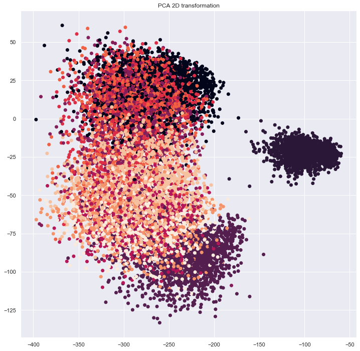

```python
plt.rcParams['figure.figsize'] = [12, 12]
plot_2D_proj(X,b) # Applying PCA and projecting in 2D
print('')
```

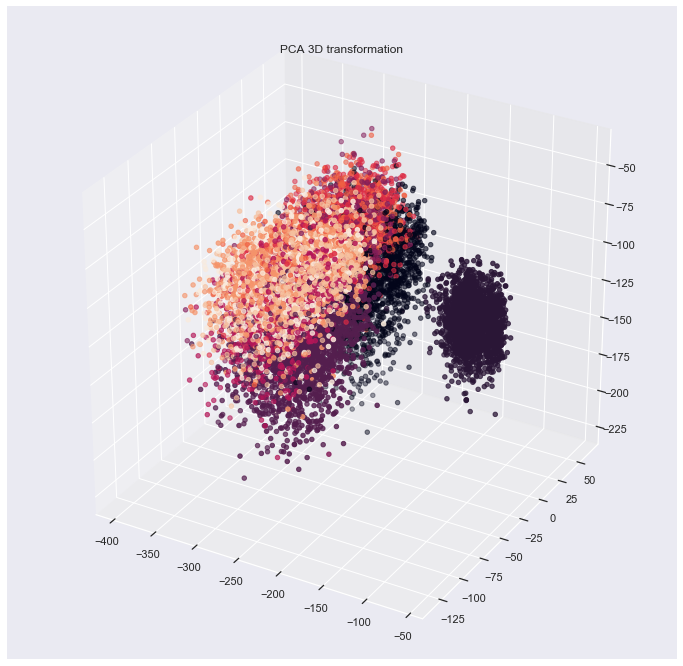

```python
plot_3D_proj(X,b) # Applying PCA and projecting in 3D
print('')
```

## Description of the Algorithms

There were three algorithms applied to the data:

1. Support Vector Machines
2. Random Forests
3. Neural Networks

#### Support Vector Machines

**Description:** A classifier that classifies data by creating a hyperplane (think of a line in 2D or plane in 3D) that seperates different classes in the data. The hyperplane also has support vectors, which are boundaries on either side of the hyperplane with the closest data points to the hyperplane on them ("edge cases" for each class are on the support vector). The hyperplane is then calculated from the datapoints from each class that are on the support vectors. SVMs also operate on the large-margin principle, which means the optimal hyperplane is the hyperplane with the largest distance between the support vectors.

**Hyperparameters:**

*kernel:* Transformation to be applied to the data before determining the hyperplane. Useful for transforming non-linearly seperable data into a higher dimension where the data is linearly seperable.

*C:* Regularization parameter that controls the trade off between misclassification and margin size. Larger C values have less misclassification and smaller margin sizes, and thus are more complex.

*gamma:* Controls how many points are considered when determining the hyperplane. Larger gamma values only include points on or extremely close to the support vectors, which results in decreased complexity since less points are considered.

#### Random Forests

**Description:** a classifier that is actually a collection of decision trees, where each decision tree is built from random splits of observations and features in the data. Each decision tree "votes" on what the class label of a point should be. The predicted class label of a new observation is then the class label with the most votes in the random forest (most votes by all the decision trees).

**Hyperparameters:**

*bagging vs boosting:* Bagging uses random partitioning of features and observations to create every decision tree randomly from the dataset. This is less complex than its counterpart, boosting. Boosting uses random samples to create trees, but the performance of every tree influences the next tree fit. Thus, each consecutive tree should have a better performance than the last. This leads to increased complexity since each fit tree has to be tested.

*n_estimators:* Number of decision trees to create for the random forest. More decision trees leads to higher complexity

*max_features:* The max number of features that can be used to split a node. Larger values lead to increased complexity

#### Neural Networks

**Description:** A classifier built on the idea of human brain neural networks. Weighted combinations of inputs (signals) are passed into a perceptron, and each perceptron contains an activation function. If the output of the activation function is above some threshold, the weighted inputs are propogated to the next perceptron (this is called forward propogation). This process is continued through each perceptron until an output is reached. The performance of the model is tested and then the error is sent backwards where the weights used on the inputs of each perceptron are updated to improve model performance (this is backpropogation). This process is repeated over the number of epochs to iteratively improve performance of the neural network.

**Hyperparameters:**

*# of hidden layers:* The number of hidden layers of perceptrons to include in the model. More hidden layers leads to increased complexity since more weights need to be updated during forward propogation and backpropogation

*# of nodes in each hidden layer:* The number of perceptrons to include in each hidden layer. More perceptrons leads to increased complexity since more weights need to be updated during backpropogation and the activation function needs to be run for each perceptron.

*activation function:* The function used to determine if weighted inputs to a perceptron should be forward propogated to the next perceptron

*learning rate:* The learning rate to be used during stochastic gradient descent. Smaller learning rates lead to increased complexity since it will take a higher number of epochs to reach the minima of the loss function

*number of epochs:* The number of iterations of forward propogation and backpropogation training to perform on the data. More epochs gives the neural network more time to adjust weights and fit the training data but also leads to increased complexity